# Political Economy

# Political Economy

> It’s the economy, stupid!

## Economics

[video not shown]

## What is The Economy?

- Is the economy how much we produce in total?
- Is the economy how much we produce per person?
- Is the economy how well we meet the needs of society?
- Is the economy how well the stock market is performing?

## Who are Economists?

- Too closely associated with business and finance
- Love to explain why you’re wrong
- Get paid too much to make predictions which don’t come true

## What is Economics?

- What we call economics today only refers to one kind of economics - the economics of capitalism.
- Capitalism is the mainstream branch of economics.
- It is hard to imagine other forms that our economy could take.

## A (Brief) History of Economics

The way the economy has been structured has changed over human history: - Hunter Gatherer Societies - Agricultural Societies - Slave Owning Production - Feudalism - Capitalism

## Political Economy - Classical Economics

- “Classical” economics is associated with the development of capitalism and the industrial revolution in the late 1700 and early 1800s.
- Marxism was a response to the horrible working conditions under which labour was subjected during the industrial revolution - and the associated disparity between capital class and working class.

## Political Economy - Modern Economics

- Class analysis was neglected in the late 1800s and early 1900s in favour of analysis of individuals.
- When thinking of economics, remember that it is ideological:
  - What kind of growth do we want?
  - Who should get the benefits of increased productivity?

## Work and Value

- Everything in the economy comes from some combination of work and the natural environment, but only work can “add value”
- There have been many attempts to define value - but clearly productive labour is the only source of it.
- Capital is not inherently ‘productive’, despite being paid profit.

## Class Consciousness and Solidarity

[video not shown]

## Class Consciousness and Solidarity

- Class is defined by the relationship between a person and the “means of production”.
- Capitalists understand the importance of class solidarity.
- Working class solidarity has been undermined by decades of neoliberal policy.

## Income Inequality

[video not shown]

## Income Inequality

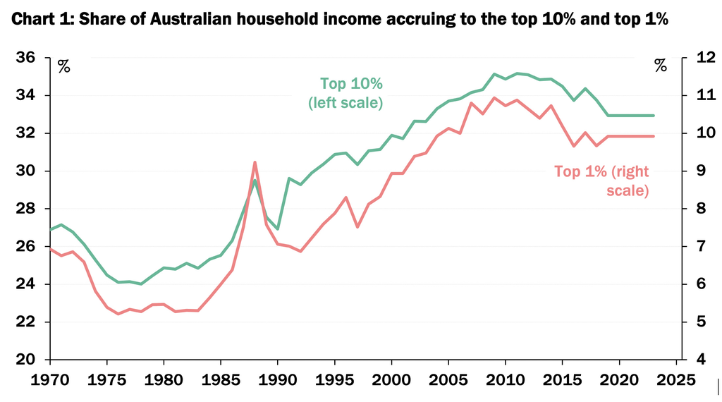

## Wealth Inequality

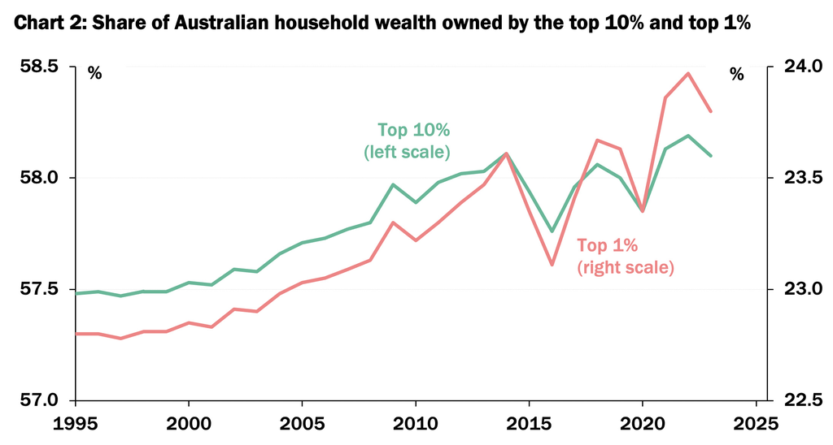